# Problem Set 1

Zhengting (Johnathan) He

2021/9/2

```r
# set working directory
require(tidyverse)
setwd("D:/OneDrive - Johns Hopkins/Course/140.621.81 - Statistical Methods in Public Health I/Problem set/jhsphbiostat621-assignment/Problem set 1")
```

# Problem set 1: Displaying and Thinking About Public Health Data EDA

## Problem 1. Air Pollution and Mortality in Baltimore

### Section 1: Exploratory Data Analysis

```r
# import data
ps1 <- read_csv("./data/baltps11.csv")
ps1$group <- factor(ps1$group, levels = c("1", "2"))
```

**a. Create stem and leaf displays by group:**

```r
for (pollut in c("1", "2")) {
    print(ifelse(pollut == "Highest", "# Daily mortality count on Highest Particulate Pollution Days",
        "# Daily mortality count on Lowest Particulate Pollution Days"))
    stem(filter(ps1, group == pollut)$deaths)
}
```

```
## [1] "# Daily mortality count on Lowest Particulate Pollution Days"
##
##   The decimal point is 1 digit(s) to the right of the |
##
##   1 | 44
##   1 | 567778899
##   2 | 334
##   2 | 5678
##   3 | 3
##   3 | 7
##
## [1] "# Daily mortality count on Lowest Particulate Pollution Days"
##
##   The decimal point is 1 digit(s) to the right of the |
##
##   1 | 134
##   1 | 5666667899
##   2 | 0134
##   2 | 577
```

**Note: R will decide the number of stems unless you control the scale. One can do this by specifying the number of lines.**

```r
for (pollut in c("1", "2")) {
    print(ifelse(pollut == "Highest", "# Daily mortality count on Highest Particulate Pollution Days",
        "# Daily mortality count on Lowest Particulate Pollution Days"))
    print("# Scale = 1")
    stem(filter(ps1, group == pollut)$deaths, scale = 1)
    print("# Scale = 3")
    stem(filter(ps1, group == pollut)$deaths, scale = 3)
}
```

```
## [1] "# Daily mortality count on Lowest Particulate Pollution Days"
## [1] "# Scale = 1"
##
##   The decimal point is 1 digit(s) to the right of the |
##
##   1 | 44
##   1 | 567778899
##   2 | 334
##   2 | 5678
##   3 | 3
##   3 | 7
##
## [1] "# Scale = 3"
##
##   The decimal point is at the |
```

[output cut: 37 more lines]

**b. Create a box and whiskers plot by group:**

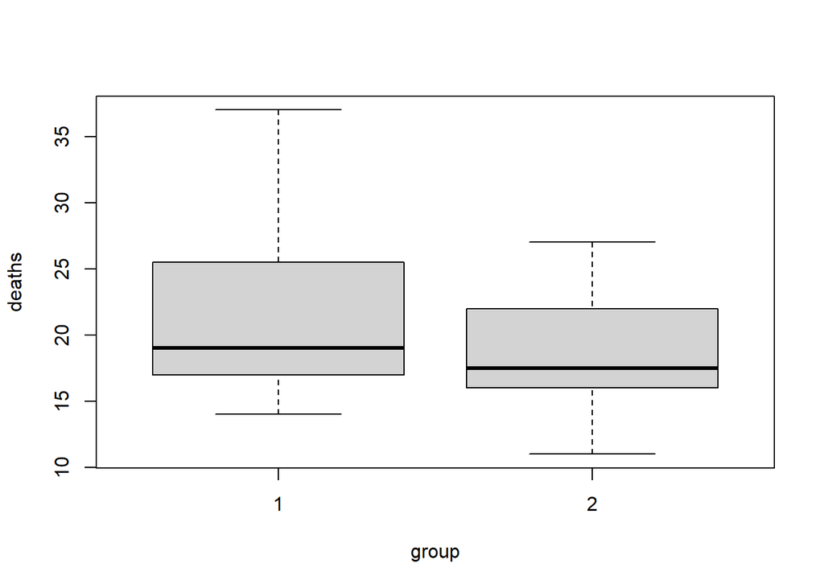

```r
boxplot(deaths ~ group, data = ps1)
```

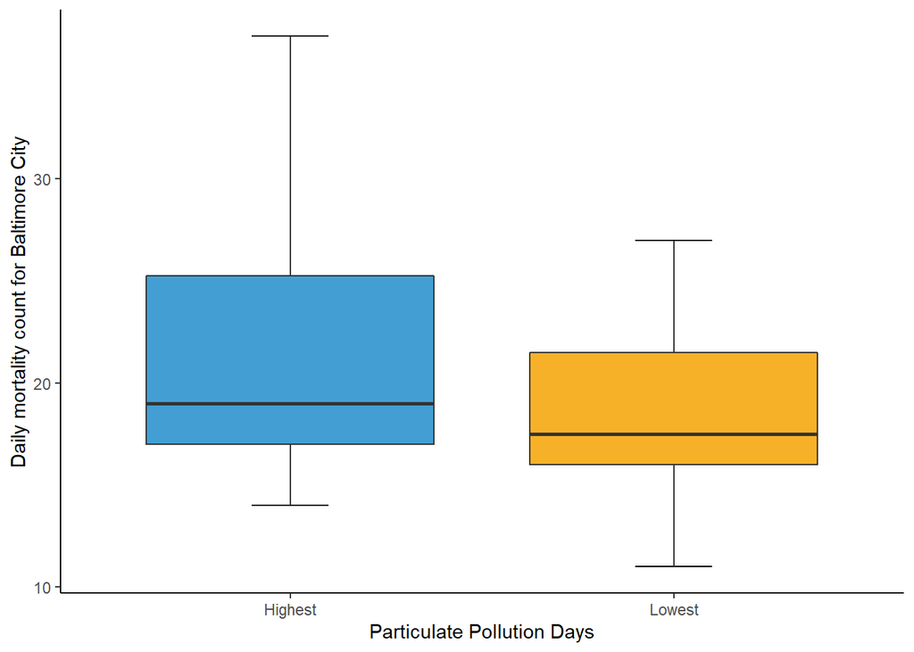

```r
ggplot(aes(x = group, y = deaths), data = ps1) + stat_boxplot(geom = "errorbar",
    width = 0.2) + geom_boxplot(aes(fill = group)) + xlab("Particulate Pollution Days") +
    ylab("Daily mortality count for Baltimore City") + scale_x_discrete(labels = c("Highest",
    "Lowest")) + scale_fill_manual(values = c("#439fd3", "#f6b128"), guide = FALSE) +
    theme_classic()
```

**c. Please check that your results for steps a. and b. give you the same results as you obtained by hand in Lab Exercise 1.**

```
# Yes.
```

**d. In a sentence or two, as if for a public health journal, summarize the evidence from these data relevant to whether mortality tends to be higher on high particulate pollution days, as compared to low particulate pollution days. Be quantitative, that is use numeric results, to describe your findings in the context of air pollution and mortality, the topic of greatest interest to your readers. Remember units!**

```
# There is a tendency for lower death on lowest particulate pollution days, since the median daily mortality count for Baltimore city is 1.5 person higher on high particulate pollution days, compared with low particulate pollution days. Since the daily mortality counts on both high particulate pollution days and low particulate pollution days are on an asymmetry distribution, it is reasonable to use median as a measurement for central tendency to compare.
```

**e. To assure reproducible research, save your script file. Please include the relevant parts of your code/output with your results as part of your write-up.**

## Problem 2. Costs of Carotid Endarterectomy in Maryland

### Section 1: Exploratory Data Analysis

**i. We have drawn a random sample of 100 male and 100 female patients from the HSCRC carotid endarterectomy data set which is located in the data file named ce621.csv on the course website. Refer to your *Class Dataset Code-Book* for the file format. Load the tidyverse with: `library(tidyverse)` Open the data set and name it ce621. And, don’t forget to open a script in order to save your work. Make stem and leaf plots of the male and female CE costs.**

```r
# import data
ce621 <- read_csv("./data/ce621.csv")
ce621$provnum <- as.numeric(ce621$provnum)
ce621$sex <- factor(ce621$sex, levels = c("Male", "Female"))
ce621$race <- factor(ce621$race, levels = c("Caucas", "AfroAm", "Other"))
ce621$smoker <- factor(ce621$smoker, levels = c("No", "Yes"))
```

```r
for (sex in c("Male", "Female")) {
    print(paste("# CE costs for ", sex, sep = ""))
    stem(filter(ce621, sex == sex)$totchg)
}
```

```
## [1] "# CE costs for Male"
##
##   The decimal point is 3 digit(s) to the right of the |
##
##    0 | 29
##    2 | 5667788990002223344445666677778899999
##    4 | 01122233333344444444455555677778999000001112222223334444556666778999
##    6 | 001122233344455566667778999900122223459
##    8 | 35577889123555779
##   10 | 12524567889
##   12 | 2588908
##   14 | 57
##   16 | 177
##   18 | 12244489
##   20 |
```

[output cut: 36 more lines]

**ii. Make the necessary calculations using R to complete the summary table below regarding CE costs by sex. To practice hand calculations, first verify that the mean, median, interquartile range (IQR), and standard deviation of the following sample of numbers: 1, 1, 1, 2, 2, 3, 5, 7, 11 are X = 3.67 ; median = 2; IQR = 4; and s = 3.43.**

**From the output generated from the above commands, complete the summary table by hand to summarize the typical value and variability of CE cost by sex.**

```r
# summary statistics
ce621.summary <- ce621 %>%
    group_by(sex) %>%
    summarise(Mean = mean(totchg, na.rm = TRUE), Median = median(totchg, na.rm = TRUE),
        IQR = quantile(totchg, probs = c(0.75), na.rm = TRUE) - quantile(totchg,
            probs = c(0.25), na.rm = TRUE), SD = sd(totchg, na.rm = TRUE))

# transform dataset to meet with the required format
ce621.summary <- ce621.summary %>%
    gather(Statistic, Value, c(Mean:SD)) %>%
    spread(sex, Value, c("Male", "Female")) %>%
    mutate(Statistic = factor(Statistic, levels = c("Mean", "Median", "IQR", "SD"))) %>%
    arrange(Statistic) %>%
    mutate(Male = round(as.numeric(Male), 2), Female = round(as.numeric(Female),
        2))
print(ce621.summary)
```

```
## # A tibble: 4 x 3
##   Statistic  Male Female
##   <fct>     <dbl>  <dbl>
## 1 Mean      6484.  8099.
## 2 Median    5598.  5644.
## 3 IQR       2862.  5187
## 4 SD        3278.  6679.
```

| Statistic | Male | Female |
| --- | --- | --- |
| Typical Value |  |  |
| Mean | 6484.04 | 8099.29 |
| Median | 5597.50 | 5643.50 |
| Variability |  |  |
| Interquartile Range (IQR) | 2861.50 | 5187.00 |
| Standard Deviation (s) | 3277.94 | 6679.28 |

**iii. In a brief paragraph, as if written for a health services research journal, compare the distribution of costs for men and women. Be quantitative by referring to the average cost, variability, and the shape of the distribution.**

```
# The average cost of women is 1615.25 dollars higher than men, and the standard deviation of cost of female is 3401.34 dollars higher than men, indicating women have a higher costs and higher variability. The shapes of the distribution of costs of both men and women are right skewed. Since the distribution of costs of both men and women are asymmetry, it may be more appropriate to use median and interquartile range to conduct summary statistics. The median cost of female is slightly higher than male (46.00 dollars), while the interquartile range of women is 2325.50 dollars higher than men, indicating a similiar (slightly higher) central cost and large variability of women compared with men.
```

**iv. Now use the entire CE data file named `CE621entire.csv`. Open the data set and name it `ce621e`. Choose only one year. Create an age category variable where age is categorized as: ≤ 50 years; 51-64; 65+.**

**Display side-by-side six box plots of the six sex-by-age strata ( ≤ 50-male, female; 51-64- male, female; 65+-male, female). Label the strata on the boxplot and order the box plots to facilitate the sex comparison within age-group.**

```r
# import dataset
ce621e <- read_csv("./data/ce621entire.csv")
ce621e$provnum <- as.numeric(ce621e$provnum)
ce621e$sex <- factor(ce621e$sex, levels = c("Male", "Female"))
ce621e$race <- factor(ce621e$race, levels = c("Caucas", "AfroAm", "Other"))
ce621e$smoker <- factor(ce621e$smoker, levels = c("No", "Yes"))
```

```r
# > max(ce621e$age)
# [1] 92

# Categorize age and sex into composite factor variable
ce621e <- ce621e %>%
              filter(year == 1995) %>% # choose year 1995
                  mutate(agecat = cut(age, breaks = c(0, 50, 64, 92))) %>%
                      mutate(agesex = case_when(agecat == "(0,50]" & sex == "Male" ~ "1",
                                                agecat == "(0,50]" & sex == "Female" ~ "2",
                                                agecat == "(50,64]" & sex == "Male" ~ "3",
                                                agecat == "(50,64]" & sex == "Female" ~ "4",
                                                agecat == "(64,92]" & sex == "Male" ~ "5",
                                                agecat == "(64,92]" & sex == "Female" ~ "6")) %>%
                          mutate(agesex = factor(agesex, levels = c("1", "2", "3", "4", "5", "6"),
                                                         labels = c("M <= 50", "F <= 50", "M 51-64",
                                                                    "F 51-64", "M >= 65", "F >= 65")))
```

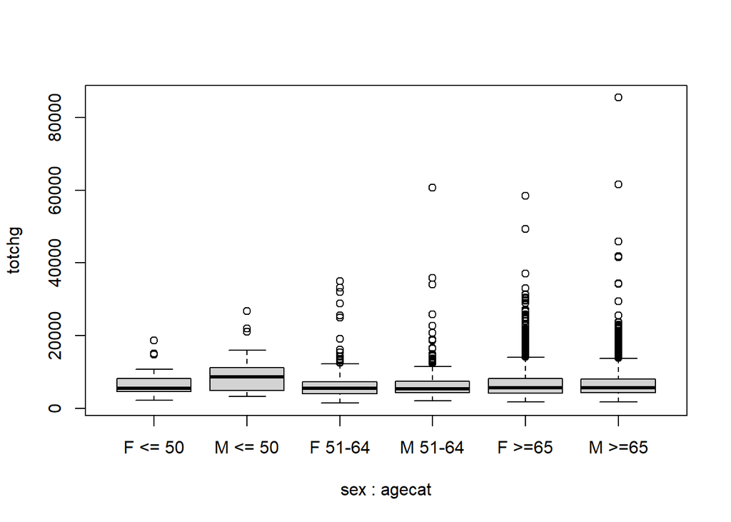

```r
boxplot(totchg ~ sex + agecat, data = ce621e, names = c("F <= 50", "M <= 50", "F 51-64",
    "M 51-64", "F >=65", "M >=65"))
```

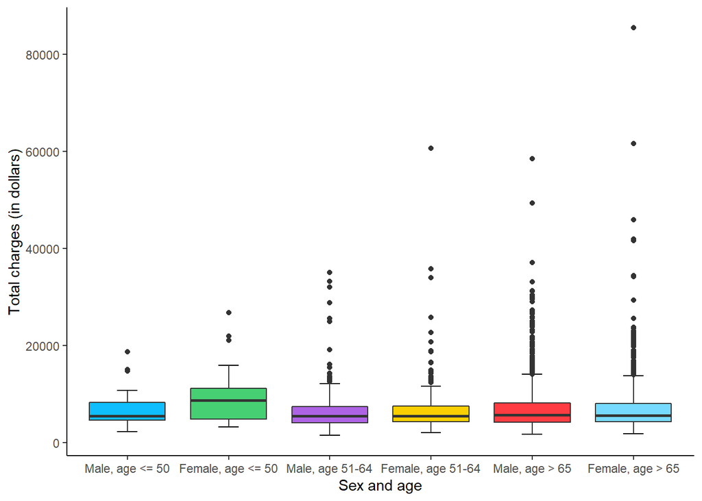

```r
ggplot(aes(x = agesex, y = totchg), data = ce621e) + stat_boxplot(geom = "errorbar",
    width = 0.2) + geom_boxplot(aes(fill = agesex)) + xlab("Sex and age") + ylab("Total charges (in dollars)") +
    scale_x_discrete(labels = c("Male, age <= 50", "Female, age <= 50", "Male, age 51-64",
        "Female, age 51-64", "Male, age > 65", "Female, age > 65")) + scale_fill_manual(values = c("#0ebeff",
    "#47cf73", "#ae63e4", "#fcd000", "#ff3c41", "#76daff"), guide = FALSE) + theme_classic()
```

**v. Write a sentence or two that describe how the CE cost distribution differs for men and women within each of the three age strata. From an equivalent but alternate perspective, describe how the distribution varies across age separately for men and women.**

```
# In the year 1995, in all age and sex groups, the distributions of total charges in dollars are right skewed.
# As for the distribution differs for men and women within each of the three age strata, among age <= 50 years, both median and interquartile range of men are lower than women, indicating a lower charges among men and lower variability. While among age group 51-64 and 65+, both median and interquartile range of men are similar (slightly higher) than women, indicating a similar (slightly higher) charges and variability among men.
# As for the distribution various across age separately for men and women, among men, the median and interquartile range between each age group are similiar. Among women, age group 51-64 has the lowest median and iterquartile range, follow by age group 65+ and <= 50, indicating the total charges with variability among age groups follow a sequence of 51-64, 65+, <= 50, from small to large. In both men and women, with age increases, the range increases in each age group.
```

**vi. Now repeat Step iv. using a logarithmic (base 10) scale for dollars. Specifically generate a new variable with log(base 10) dollars. How does this display compare with the previous one using the original scale? What additional patterns are made apparent?**

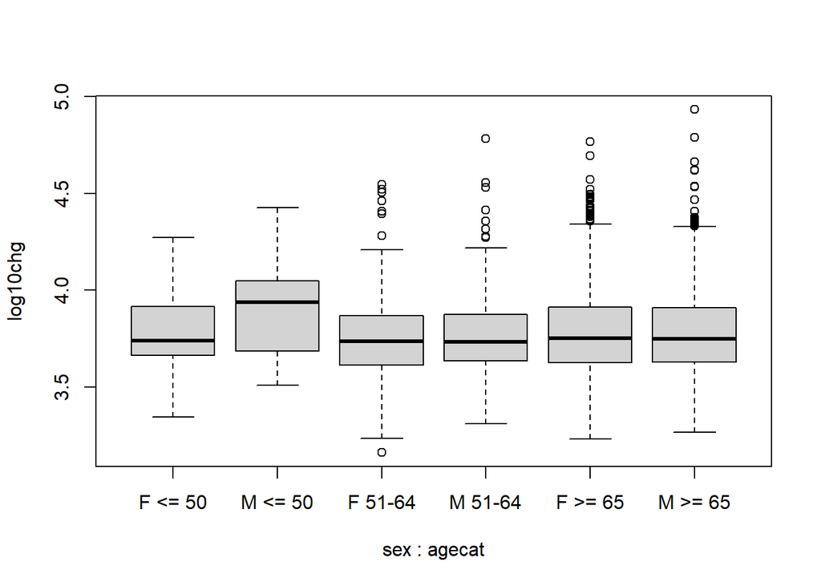

```r
ce621e <- ce621e %>%
    mutate(log10chg = log10(totchg))

boxplot(log10chg ~ sex + agecat, data = ce621e, names = c("F <= 50", "M <= 50", "F 51-64",
    "M 51-64", "F >= 65", "M >= 65"))
```

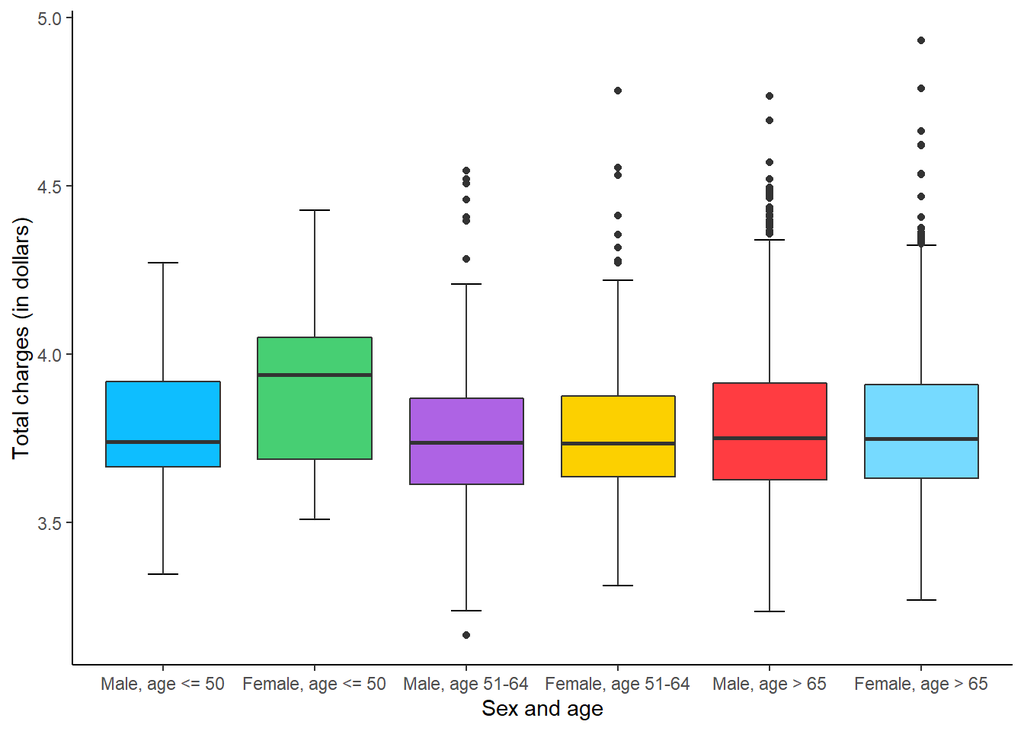

[output not shown]

```r
ggplot(aes(x = agesex, y = log10chg), data = ce621e) + stat_boxplot(geom = "errorbar",
    width = 0.2) + geom_boxplot(aes(fill = agesex)) + xlab("Sex and age") + ylab("Total charges (in dollars)") +
    scale_x_discrete(labels = c("Male, age <= 50", "Female, age <= 50", "Male, age 51-64",
        "Female, age 51-64", "Male, age > 65", "Female, age > 65")) + scale_fill_manual(values = c("#0ebeff",
    "#47cf73", "#ae63e4", "#fcd000", "#ff3c41", "#76daff"), guide = FALSE) + theme_classic()
```

**vii. To assure reproducible research, save your script file. Please include the relevant parts of your code/output with your results as part of your write-up.**